The human activity recognition is a vast domain which was researched quite fairly. However most of the research papers available focus on drawing a distinction between the activities not how well they will perform. Hence the question of this research will be to investigate how well a person can do an activity via Machine learning algorithms. 1- we will start by collecting data. to do so ( 6 participants were asked to perform one set of 10 repetitions of the Unilateral Dumbbell Biceps Curl in five different fashions: exactly according to the specification (Class A), throwing the elbows to the front (Class B), lifting the dumbbell only halfway (Class C), lowering the dumbbell only halfway (Class D) and throwing the hips to the front (Class E) - you can find more details here http://groupware.les.inf.puc-rio.br/har)

we will first remove the columns that are empty ( Na) then we will remove the identification columns which fairly speaking will not serve a lot because the 6 participants are equally performant and share the same interval of age. After we will remove the variables that have a variance near zero. Finally we show the dimensions of the new tables to show how much we removed.

```
## [1] 19622    93
```

```
## [1] 19622    88
```

```
## [1] 19622    54
```

Finally we visualize the correlations between the remaining variables as a rule of thumb a correlation of more than 0.8 is considered very high and a PCA should be executed. However from the plot we find that the variables that are correlated are very rare so to not lose information and computational time and for the sake of interpretability, speed and simplicity of course we don’t do PCA (we sacrifice a little accuracy)

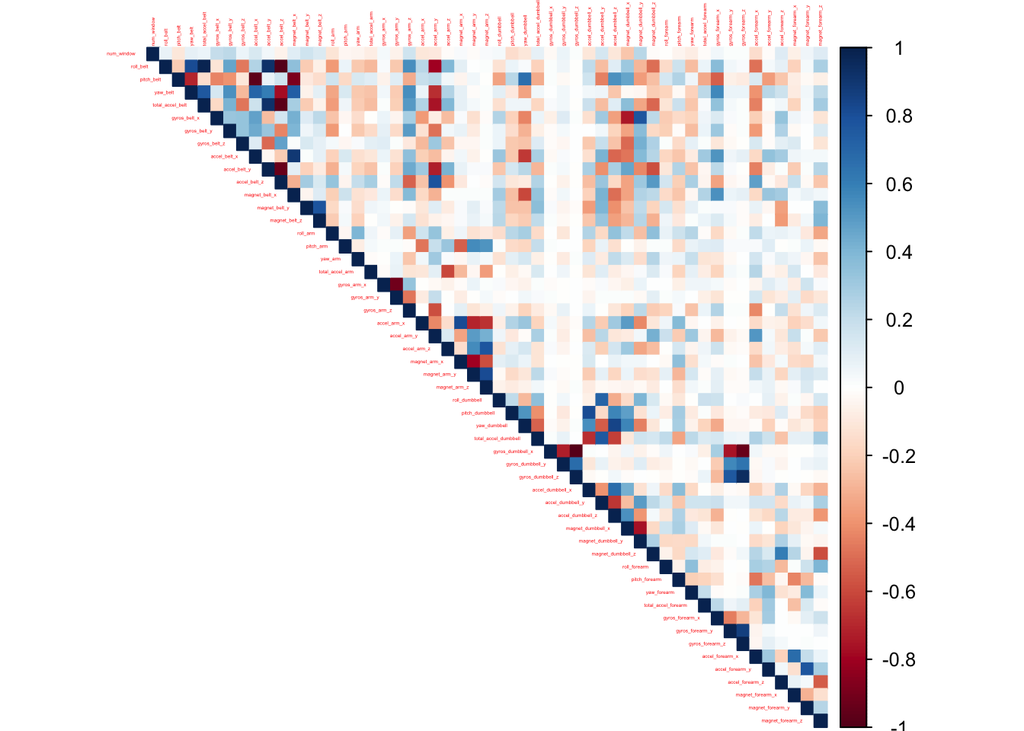

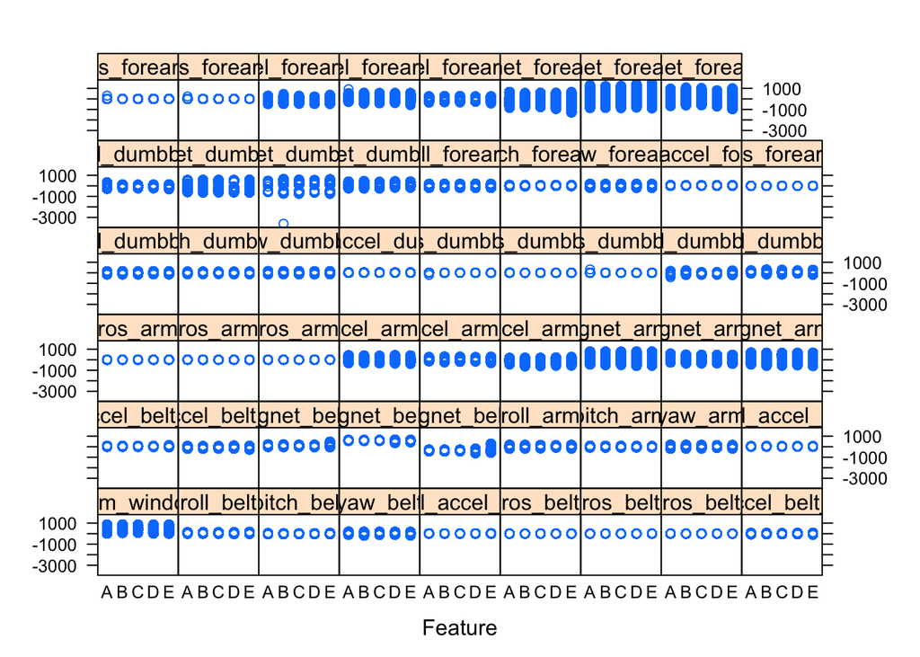

Considering the features plot it is a way to look at all the data and it appears that there isnt any strange pattern however we can all agree that its a little bit hard to interpret knowing that it is a very small plot. Also we can clearly see that there is not some strange pattern or deviance so we assume there is no need for scaling and centering the data.

we start by fitting the algorithms and looking at their estimated OSE : we choose three algorithms to begin with and we will be trying to do some stacking at the end for the sake of accuracy.

The first algorithm is Random forests which can be considered as the decision resulting from multiple decision trees that investigate each variable and here each movement to be able to predict the class.

```
##
## Call:
##  randomForest(x = x, y = y, mtry = param$mtry)
##                Type of random forest: classification
##                      Number of trees: 500
## No. of variables tried at each split: 27
##
##         OOB estimate of  error rate: 0.22%
## Confusion matrix:
##      A    B    C    D    E  class.error
## A 4183    1    0    0    1 0.0004778973
## B    4 2838    5    1    0 0.0035112360
## C    0    5 2561    1    0 0.0023373588
## D    0    0    8 2403    1 0.0037313433
## E    0    0    0    5 2701 0.0018477458
```

```
## Confusion Matrix and Statistics
##
##           Reference
## Prediction    A    B    C    D    E
##          A 1395    4    0    0    0
##          B    0  945    0    0    0
##          C    0    0  855    2    0
##          D    0    0    0  802    1
##          E    0    0    0    0  900
##
## Overall Statistics
##
##                Accuracy : 0.9986
##                  95% CI : (0.9971, 0.9994)
##     No Information Rate : 0.2845
##     P-Value [Acc > NIR] : < 2.2e-16
##
##                   Kappa : 0.9982
##
##  Mcnemar's Test P-Value : NA
##
## Statistics by Class:
##
##                      Class: A Class: B Class: C Class: D Class: E
## Sensitivity            1.0000   0.9958   1.0000   0.9975   0.9989
## Specificity            0.9989   1.0000   0.9995   0.9998   1.0000
## Pos Pred Value         0.9971   1.0000   0.9977   0.9988   1.0000
## Neg Pred Value         1.0000   0.9990   1.0000   0.9995   0.9998
## Prevalence             0.2845   0.1935   0.1743   0.1639   0.1837
## Detection Rate         0.2845   0.1927   0.1743   0.1635   0.1835
## Detection Prevalence   0.2853   0.1927   0.1748   0.1637   0.1835
## Balanced Accuracy      0.9994   0.9979   0.9998   0.9986   0.9994
```

The second algorithm is decision trees and we use it to see if a much simpler machine learning technique will give us a very good result near the one of the Random forest.

```
## n= 14718
##
## node), split, n, loss, yval, (yprob)
##       * denotes terminal node
##
##  1) root 14718 10533 A (0.28 0.19 0.17 0.16 0.18)
##    2) roll_belt< 129.5 13400  9269 A (0.31 0.21 0.19 0.18 0.11)
##      4) pitch_forearm< -33.95 1202     8 A (0.99 0.0067 0 0 0) *
##      5) pitch_forearm>=-33.95 12198  9261 A (0.24 0.23 0.21 0.2 0.12)
##       10) num_window>=45.5 11648  8711 A (0.25 0.24 0.22 0.2 0.086)
##         20) num_window< 241.5 2603  1210 A (0.54 0.13 0.11 0.19 0.038) *
##         21) num_window>=241.5 9045  6532 B (0.17 0.28 0.25 0.2 0.1)
##           42) magnet_dumbbell_z< -23.5 2534  1352 A (0.47 0.35 0.053 0.12 0.0083) *
##           43) magnet_dumbbell_z>=-23.5 6511  4354 C (0.056 0.25 0.33 0.23 0.14)
##             86) magnet_dumbbell_x>=-445.5 1868   990 B (0.04 0.47 0.063 0.17 0.25) *
##             87) magnet_dumbbell_x< -445.5 4643  2604 C (0.062 0.16 0.44 0.25 0.087) *
##       11) num_window< 45.5 550   109 E (0 0 0 0.2 0.8) *
##    3) roll_belt>=129.5 1318    54 E (0.041 0 0 0 0.96) *
```

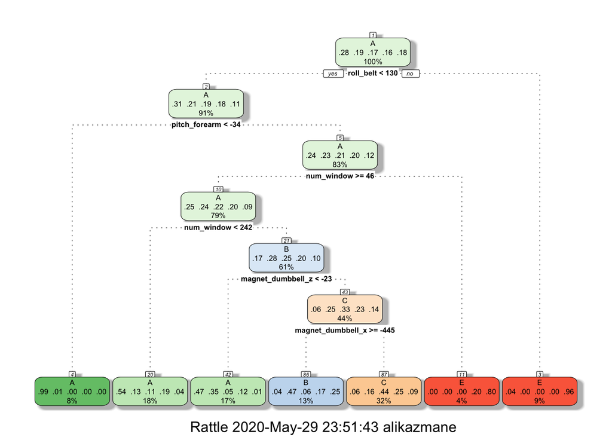

```
## Confusion Matrix and Statistics
##
##           Reference
## Prediction    A    B    C    D    E
##          A 1229  411  157  296   42
##          B   30  285   32  112  166
##          C  116  253  666  359  126
##          D    0    0    0    0    0
##          E   20    0    0   37  567
##
## Overall Statistics
##
##                Accuracy : 0.5602
##                  95% CI : (0.5461, 0.5741)
##     No Information Rate : 0.2845
##     P-Value [Acc > NIR] : < 2.2e-16
##
##                   Kappa : 0.4318
##
##  Mcnemar's Test P-Value : < 2.2e-16
##
## Statistics by Class:
##
##                      Class: A Class: B Class: C Class: D Class: E
## Sensitivity            0.8810  0.30032   0.7789   0.0000   0.6293
## Specificity            0.7418  0.91403   0.7891   1.0000   0.9858
## Pos Pred Value         0.5756  0.45600   0.4382      NaN   0.9087
## Neg Pred Value         0.9401  0.84482   0.9441   0.8361   0.9220
## Prevalence             0.2845  0.19352   0.1743   0.1639   0.1837
## Detection Rate         0.2506  0.05812   0.1358   0.0000   0.1156
## Detection Prevalence   0.4354  0.12745   0.3100   0.0000   0.1272
## Balanced Accuracy      0.8114  0.60717   0.7840   0.5000   0.8075
```

the third algorithm which is the gradient boosting model using trees which correct each the errors made by the previous trees and GBM does not simply average them like the Random forest algorithm but this model is more overfitting friendly.

```
## A gradient boosted model with multinomial loss function.
## 150 iterations were performed.
## There were 53 predictors of which 53 had non-zero influence.
```

```
## Confusion Matrix and Statistics
##
##           Reference
## Prediction    A    B    C    D    E
##          A 1393   13    0    0    0
##          B    2  917    6    3    3
##          C    0   19  844    3    1
##          D    0    0    5  796    8
##          E    0    0    0    2  889
##
## Overall Statistics
##
##                Accuracy : 0.9867
##                  95% CI : (0.9831, 0.9898)
##     No Information Rate : 0.2845
##     P-Value [Acc > NIR] : < 2.2e-16
##
##                   Kappa : 0.9832
##
##  Mcnemar's Test P-Value : NA
##
## Statistics by Class:
##
##                      Class: A Class: B Class: C Class: D Class: E
## Sensitivity            0.9986   0.9663   0.9871   0.9900   0.9867
## Specificity            0.9963   0.9965   0.9943   0.9968   0.9995
## Pos Pred Value         0.9908   0.9850   0.9735   0.9839   0.9978
## Neg Pred Value         0.9994   0.9919   0.9973   0.9980   0.9970
## Prevalence             0.2845   0.1935   0.1743   0.1639   0.1837
## Detection Rate         0.2841   0.1870   0.1721   0.1623   0.1813
## Detection Prevalence   0.2867   0.1898   0.1768   0.1650   0.1817
## Balanced Accuracy      0.9974   0.9814   0.9907   0.9934   0.9931
```

```
##           Model  Accuracy
## 1 Random Forest 0.9985726
## 2 decision tree 0.5601550
## 3           GBM 0.9867455
```

From the results that we have seen we can clearly see that the Random forest is the best performing model for Accuracy and hence for the OSE so we choose it to apply for our prediction on the testing data.

The GBM is very close to RF but normaly it involves more overfitting so the perfect predictor is the random forest one

```
##  [1] B A B A A E D B A A B C B A E E A B B B
## Levels: A B C D E
```

So as everyone can see we get our data it is very clear that the Random Forest performs better and that it does well in predictiong the class however there may be some overfitting and we didnot perform the stacking as the Random forest is enough and stacking will only increase the overfitting. Now personnaly for machine learning i believe in the theory of double descent however for such clear project and question the model do not need to be very complicated.

Pollution is growing in Korea at an exponential rate so to avoid a catatstrophic event where the air is polluted and people start dying from it Korea needs to reduce its air pollution but it also needs to do it in a range of time. So the question is mainly to discover how much time they got left to act. This project will basically need some acknowledgment for time series modelling we will study the trends and use the data of each pollutant with removing the identifications columns of stations ….

Then after we will use some algorithms and mainly LSTM which i am familiar with even though it wasnt included in the course